# Impact of Hiring New H-1B Workers on Wages in the Health Care Sector

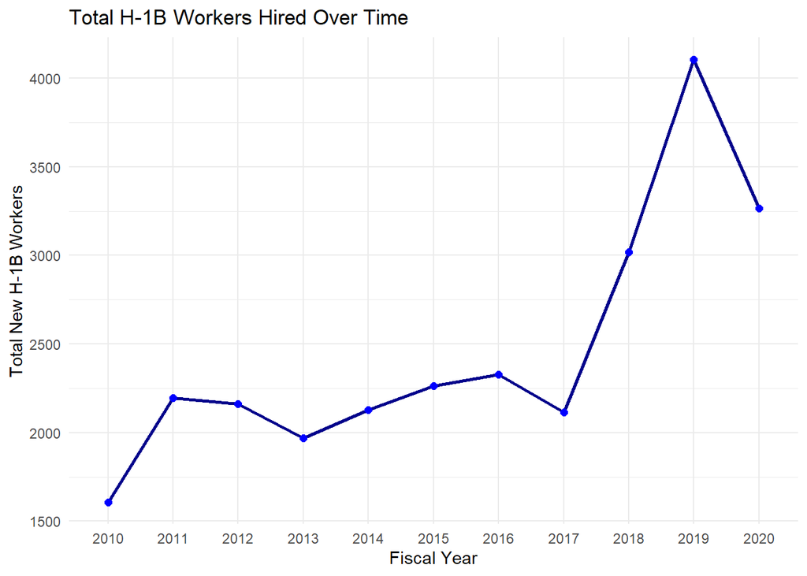

```r
# Line plot: Total H-1B hiring over time
h1b_trends <- finance_data %>%
  group_by(DataYearFiscal) %>%
  summarize(total_h1bs = sum(newh1bs, na.rm = TRUE))

ggplot(h1b_trends, aes(x = as.factor(DataYearFiscal), y = total_h1bs, group = 1)) +
  geom_line(color = "darkblue", size = 1) +
  geom_point(color = "blue", size = 2) +
  labs(title = "Total H-1B Workers Hired Over Time",
       x = "Fiscal Year",
       y = "Total New H-1B Workers") +
  theme_minimal()
```

# The model

```r
# Convert fiscal year to factor
finance_data <- finance_data %>%
  mutate(DataYearFiscal = as.factor(DataYearFiscal)) %>%
  select(high_wage, newh1bs, AssetsTotal, DataYearFiscal)

finance_data_clean <- na.omit(finance_data)

# Fit the Binary Logit Model
model <- glm(high_wage ~ newh1bs + AssetsTotal + newh1bs:AssetsTotal + DataYearFiscal,
             data = finance_data_clean, family = binomial)

# Summarize model results
summary(model)
```

```
##
## Call:
## glm(formula = high_wage ~ newh1bs + AssetsTotal + newh1bs:AssetsTotal +
##     DataYearFiscal, family = binomial, data = finance_data_clean)
##
## Coefficients:
##                       Estimate Std. Error z value Pr(>|z|)
## (Intercept)          3.930e+00  4.519e-01   8.697  < 2e-16 ***
## newh1bs             -9.965e-04  3.199e-03  -0.312  0.75541
## AssetsTotal          1.859e-06  8.470e-07   2.194  0.02820 *
## DataYearFiscal2011  -1.451e-02  6.384e-01  -0.023  0.98187
## DataYearFiscal2012   2.469e-01  6.764e-01   0.365  0.71504
## DataYearFiscal2013   2.553e-01  6.764e-01   0.378  0.70579
## DataYearFiscal2014  -1.263e+00  5.163e-01  -2.446  0.01446 *
## DataYearFiscal2015  -1.269e+00  5.163e-01  -2.457  0.01401 *
## DataYearFiscal2016  -1.287e+00  5.164e-01  -2.492  0.01272 *
## DataYearFiscal2017  -1.321e+00  5.166e-01  -2.557  0.01056 *
## DataYearFiscal2018  -1.350e+00  5.168e-01  -2.613  0.00897 **
## DataYearFiscal2019  -1.427e+00  5.141e-01  -2.776  0.00551 **
## DataYearFiscal2020  -1.476e+00  5.141e-01  -2.872  0.00408 **
## newh1bs:AssetsTotal  9.353e-09  2.432e-08   0.385  0.70058
## ---
## Signif. codes:  0 '***' 0.001 '**' 0.01 '*' 0.05 '.' 0.1 ' ' 1
##
## (Dispersion parameter for binomial family taken to be 1)
##
##     Null deviance: 1141.0  on 3168  degrees of freedom
## Residual deviance: 1076.3  on 3155  degrees of freedom
## AIC: 1104.3
##
## Number of Fisher Scoring iterations: 10
```

```r
## Look at fitted choice probabilities
fitted(model, type = 'probabilities') %>%
  head()
```

```
##         1         2         3         4         5         6
## 0.9820129 0.9817493 0.9859398 0.9863116 0.9405325 0.9400123
```

```r
### predicitons for the proabilities and make a new dataset to change new h1b's by 1 to see how it changes the probabilities
```

```r
## Look at fitted choice probabilities
fitted_probabilities <- fitted(model, type = 'probabilities')

fitted_probabilities%>%
  head()
```

```
##         1         2         3         4         5         6
## 0.9820129 0.9817493 0.9859398 0.9863116 0.9405325 0.9400123
```

```r
# Create a new dataset with `new_h1b` increased by 1
new_data <- finance_data_clean %>%
  mutate(newh1bs = newh1bs + 1)

# Predict probabilities using the updated dataset
new_fitted_probabilities <- predict(model, newdata = new_data, type = "response")

# Compare old and new probabilities
comparison <- finance_data_clean %>%
  mutate(original_prob = fitted_probabilities,
         new_prob = new_fitted_probabilities,
         change_in_prob = new_prob - original_prob)

# Display the first few rows of the comparison
summary_1 <- summary(comparison)
summary_1
```

```
##    high_wage         newh1bs         AssetsTotal      DataYearFiscal
##  Min.   :0.0000   Min.   :  0.000   Min.   :      0   2013   : 302
##  1st Qu.:1.0000   1st Qu.:  0.000   1st Qu.:   1216   2012   : 299
##  Median :1.0000   Median :  0.000   Median :   6332   2014   : 297
##  Mean   :0.9561   Mean   :  8.053   Mean   : 162690   2015   : 296
##  3rd Qu.:1.0000   3rd Qu.:  1.000   3rd Qu.:  38830   2016   : 292
##  Max.   :1.0000   Max.   :547.000   Max.   :3386071   2010   : 291
##                                                       (Other):1392
##  original_prob       new_prob      change_in_prob
##  Min.   :0.8775   Min.   :0.8774   Min.   :-1.057e-04
##  1st Qu.:0.9330   1st Qu.:0.9330   1st Qu.:-6.009e-05
##  Median :0.9407   Median :0.9407   Median :-1.909e-05
##  Mean   :0.9561   Mean   :0.9561   Mean   :-2.710e-05
##  3rd Qu.:0.9849   3rd Qu.:0.9849   3rd Qu.:-1.335e-05
##  Max.   :1.0000   Max.   :1.0000   Max.   : 1.238e-04
##
```

```r
#summary_1 <- cbind(Statistic = rownames(summary_1), summary_1)
```

```r
# summary_1 %>%
#   kable("html", caption = "Summary Statistics of Finance Dataset") %>%
#   kable_styling(bootstrap_options = c("striped", "hover", "condensed", "responsive"),
#                 full_width = FALSE,
#                 position = "left") %>%
#   row_spec(0, bold = TRUE, background = "lightblue")
```

```r
# Create a new dataset with `new_h1b` increased by 1
new_data_asset <- finance_data_clean %>%
  mutate(newh1bs = AssetsTotal + 1)

# Predict probabilities using the updated dataset
new_fitted_probabilities <- predict(model, newdata  = new_data_asset, type = "response")

# Compare old and new probabilities
comparison_2 <- finance_data_clean %>%
  mutate(original_prob = fitted_probabilities,
         new_prob = new_fitted_probabilities,
         change_in_prob = new_prob - original_prob)

# Display the first few rows of the comparison
summary_2 <- summary(comparison_2)
summary_2
```

```
##    high_wage         newh1bs         AssetsTotal      DataYearFiscal
##  Min.   :0.0000   Min.   :  0.000   Min.   :      0   2013   : 302
##  1st Qu.:1.0000   1st Qu.:  0.000   1st Qu.:   1216   2012   : 299
##  Median :1.0000   Median :  0.000   Median :   6332   2014   : 297
##  Mean   :0.9561   Mean   :  8.053   Mean   : 162690   2015   : 296
##  3rd Qu.:1.0000   3rd Qu.:  1.000   3rd Qu.:  38830   2016   : 292
##  Max.   :1.0000   Max.   :547.000   Max.   :3386071   2010   : 291
##                                                       (Other):1392
##  original_prob       new_prob        change_in_prob
##  Min.   :0.8775   Min.   :0.000000   Min.   :-0.987233
##  1st Qu.:0.9330   1st Qu.:0.005273   1st Qu.:-0.926717
##  Median :0.9407   Median :0.766515   Median :-0.181542
##  Mean   :0.9561   Mean   :0.547316   Mean   :-0.408822
##  3rd Qu.:0.9849   3rd Qu.:0.967718   3rd Qu.:-0.008794
##  Max.   :1.0000   Max.   :1.000000   Max.   : 0.065037
##
```

```r
# Extract and format model results
library(broom)
library(kableExtra)

results_table <- tidy(model) %>%
  mutate(significance = ifelse(p.value < 0.05, "*", "")) %>%
  select(term, estimate, std.error, p.value, significance)

# Display the results
kable(results_table, caption = "Binary Logit Model Results") %>%
  kable_classic(full_width = FALSE, html_font = "Cambria") %>%
  row_spec(0, bold = TRUE, background = "lightblue")
```

Binary Logit Model Results

term

estimate

std.error

p.value

significance

(Intercept)

3.9304485

0.4519243

0.0000000

newh1bs

-0.0009965

0.0031989

0.7554140

AssetsTotal

0.0000019

0.0000008

0.0282025

DataYearFiscal2011

-0.0145067

0.6384481

0.9818722

DataYearFiscal2012

0.2469334

0.6763642

0.7150447

DataYearFiscal2013

0.2553387

0.6763641

0.7057897

DataYearFiscal2014

-1.2627237

0.5162942

0.0144553

DataYearFiscal2015

-1.2685520

0.5163219

0.0140141

DataYearFiscal2016

-1.2866982

0.5164172

0.0127174

DataYearFiscal2017

-1.3207922

0.5165561

0.0105604

DataYearFiscal2018

-1.3504496

0.5167980

0.0089723

DataYearFiscal2019

-1.4269791

0.5141124

0.0055097

DataYearFiscal2020

-1.4763155

0.5140968

0.0040831

newh1bs:AssetsTotal

0.0000000

0.0000000

0.7005794

```r
  # add_header_above(c(" " = 1, "Average Wage (A_MEAN)" = 4, "New H-1B Workers" = 4)) %>%
  # column_spec(1, bold = TRUE)
```

# 2 Introducing the data - Graphs

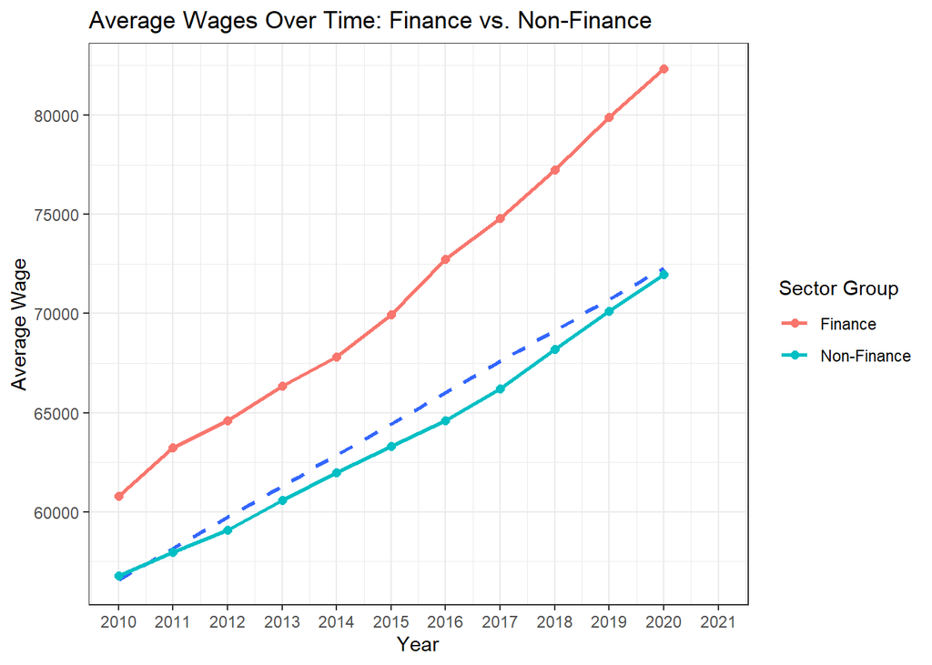

```r
data <- data %>%
  mutate(finance = if_else(industry_group == "52","Finance","Non-Finance"))


data %>%
  ggplot(aes(x = DataYearFiscal, y = A_MEAN)) +
  geom_smooth(method = "lm", se = FALSE, linetype = "dashed", size = 1)+
  geom_line(aes(color = finance),stat = "summary", fun = "mean", size = 1) +
  geom_point(aes(color = finance),stat = "summary", fun = "mean", size = 2)+
  labs(
    title = "Average Wages Over Time: Finance vs. Non-Finance",
    x = "Year",
    y = "Average Wage",
    color = "Sector Group"
  )+
  scale_x_continuous(breaks = seq(2010,2021,1), limits = c(2010,2021))+
  theme_bw()
```

*NOTE: Fiance over time is a higher paying sector on average, then the non-finance firms wages* *NOTE: NO WAGE DATA FOR THE YEAR 2021*

## 2.1 H1b visa employees over time: finance vs non-finance

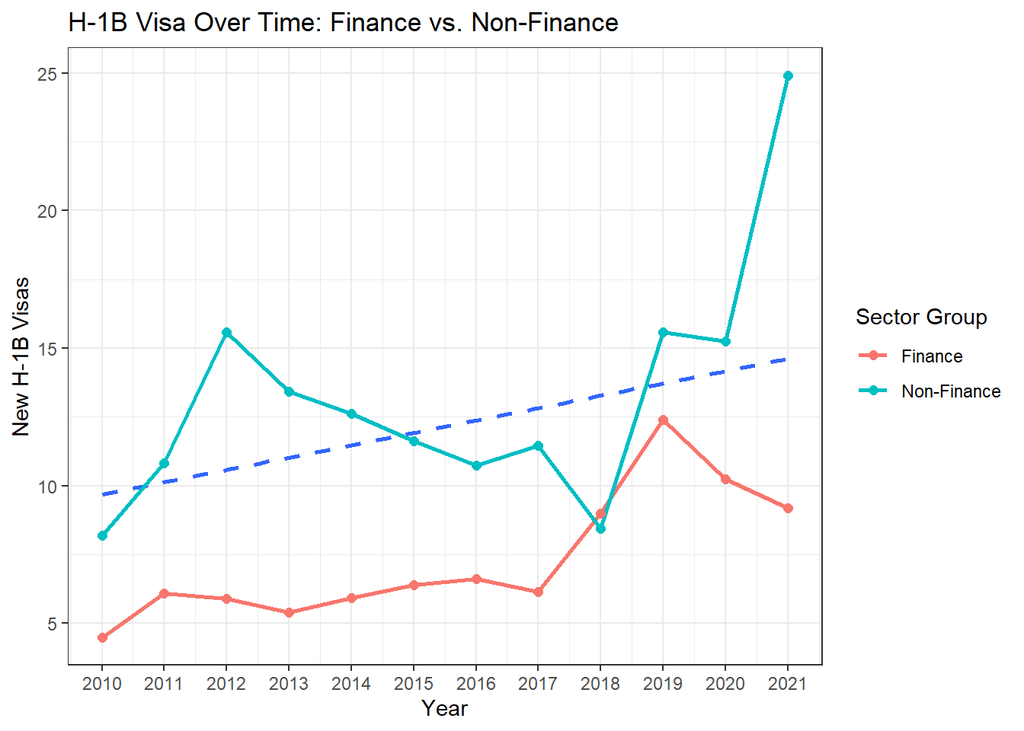

```r
data %>%
  ggplot(aes(x = DataYearFiscal, y = newh1bs)) +
  geom_smooth(method = "lm", se = FALSE, linetype = "dashed", size = 1)+
  geom_line(aes(color = finance),stat = "summary", fun = "mean", size = 1) +
  geom_point(aes(color = finance),stat = "summary", fun = "mean", size = 2)+
  labs(
    title = "H-1B Visa Over Time: Finance vs. Non-Finance",
    x = "Year",
    y = "New H-1B Visas",
    color = "Sector Group"
  )+
  scale_x_continuous(breaks = seq(2010,2021,1), limits = c(2010,2021))+
  theme_bw()
```

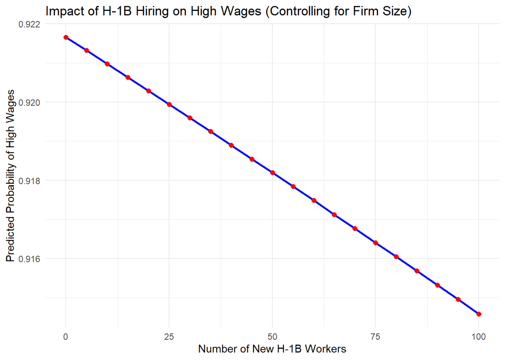

```r
# Create a dataset for prediction with firm size fixed (e.g., median size)
prediction_data <- data.frame(
  newh1bs = seq(0, 100, 5),  # Varying H-1B hiring levels
  AssetsTotal = median(finance_data$AssetsTotal, na.rm = TRUE),  # Fix firm size
  DataYearFiscal = "2020"  # Example year
)

# Predict probabilities
prediction_data$predicted_prob <- predict(model, newdata = prediction_data, type = "response")

# Plot the effect of H-1B hiring on high wages
ggplot(prediction_data, aes(x = newh1bs, y = predicted_prob)) +
  geom_line(color = "blue", size = 1) +
  geom_point(color = "red", size = 2) +
  labs(
    title = "Impact of H-1B Hiring on High Wages (Controlling for Firm Size)",
    x = "Number of New H-1B Workers",
    y = "Predicted Probability of High Wages"
  ) +
  theme_minimal()
```